# تحليل بيانات Bulk RNA-Seq باستخدام R

### ورشة عمل مقامة يوم 11 أكتوبر 2025 في مدينة أكسفورد

### نرحب بالتواصل معكم من خلال وسائل التواصل التالية:

### [YouTube](http://www.youtube.com/@Dalah-info) | [X](https://x.com/Dalah_Info) | [LinkedIn](https://www.linkedin.com/company/dalah/) | [GitHub](https://github.com/Dalah-Info)

# 🧬 مقدمة: ما هو تحليل الـ RNA-seq؟

## ما الذي نقيسه في تجربة RNA-seq؟

تحليل **RNA-seq** هو أحد أهم التقنيات في علم الجينوم الوظيفي،  
ويُستخدم لقياس **كمية التعبير الجيني** لكل جين في خلية أو نسيج.

في هذه التقنية، يتم:

1. استخلاص الـ RNA من العينات (مثل نسيج طبيعي أو نسيج ورمي).
2. تحويله إلى cDNA وقراءة تسلسله
3. حساب عدد القراءات (Reads) التي تمثل كل جين في كل عينة.

> 💡 هذه العدّات هي البيانات الأساسية التي سنحللها اليوم.

## الفرق بين Bulk RNA-seq وSingle-cell RNA-seq

| النوع | الهدف | التباين | ملاحظات |
| --- | --- | --- | --- |
| **Bulk RNA-seq** | قياس التعبير المتوسط لمجموعة خلايا (مثل نسيج كامل). | لا يُظهر تباين الخلايا المفردة. | يستخدم في المقارنات بين المجموعات (مثل طبيعي مقابل ورمي). |
| **Single-cell RNA-seq** | قياس التعبير لكل خلية على حدة. | يكشف التغاير داخل النسيج. | يتطلب تحليلًا أكثر تعقيدًا. |

> في هذه الورشة سنعمل على **Bulk RNA-seq** لأنها الأنسب لاكتشاف الجينات المختلفة بين الحالات.

## كيف تُخزّن بيانات RNA-seq؟

عادةً نحصل على ملفين أساسيين:

1. **Count matrix:**
   - الصفوف = الجينات (Gene IDs)
   - الأعمدة = العينات (Samples)
   - القيم = عدد القراءات لكل جين في كل عينة
2. **Metadata (أو Design file):**
   - يحتوي على معلومات وصفية عن العينات (مثل نوع العينة، الحالة المرضية، مصدر النسيج…)
   - يربط كل عينة باسمها الموجود في جدول العدّات

> ✨ بدمج الملفين يمكننا معرفة أي قراءة تخص أي عينة وأي حالة مرضية.

## الهدف من تحليل البيانات

هدفنا في هذه الورشة هو تحليل بيانات RNA-seq لمجموعة من عينات **سرطان القولون**،  
لدراسة الاختلاف في التعبير الجيني بين:

> **Primary tumor** vs **Solid tissue normal**

وسنقوم بـ:

1. تنظيف البيانات وتصفية الجينات منخفضة التعبير.
2. إجراء التحليل باستخدام **DESeq2**.
3. رسم المخططات التفسيرية (PCA, Volcano, Boxplot, Violin).
4. Pathway Enrichment Analysis.
5. وفي النهاية، سنطبق عمليًا على مقارنة أخرى.

## الخطوات العامة للتحليل

1. قراءة ملفات Counts والبيانات الوصفية.
2. تصفية الجينات منخفضة التعبير.
3. تحليل الفروق بين المجموعات (**DESeq2**).
4. تحويل البيانات (**VST**).
5. رسم العينات والجينات (**PCA** و**Volcano**).
6. تحليل للوظائف المتأثرة.

# 0. تهيئة بيئة العمل وتحميل الحزم البرمجية

> **متطلب سابق للورشة:**  
> يرجى التأكد من تشغيل ملف  
> `install_packages_bulkRNAseq.R`  
> قبل بدء الورشة لتثبيت الحزم اللازمة.  
> ⚠️ ملاحظة: هذه الخطوة مهمة فقط إذا لم تكن الحزم مثبتة مسبقًا على جهازك.  
> بعد التثبيت لمرة واحدة، يمكن تجاهلها والاكتفاء باستخدام `library()` لاحقًا.  
> 📺 لمشاهدة شرح تثبيت الحزم من CRAN / GitHub / Bioconductor:  
> [طريقة تثبيت الحزم في R](https://youtu.be/AQpDAl2yfLM?si=iGebpOznDkZOIlBS)

## 0.1 الحزم المستخدمة وهدف كل منها

**`library(tidyverse)`**  
> تُحمِّل مجموعة من الحزم المتكاملة مثل `dplyr`, `ggplot2`, و `readr`  
> لتسهيل التعامل مع البيانات وتنظيفها وتحليلها.  
> 🔗 https://www.tidyverse.org

**`library(DESeq2)`**  
> الحزمة الأساسية لتحليل بيانات التعبير الجيني التفاضلي (RNA-seq).  
> تعتمد على نموذج **Negative Binomial** وتقدّم تحليلًا إحصائيًا دقيقًا.  
> 🔗 https://bioconductor.org/packages/release/bioc/html/DESeq2.html

**`library(AnnotationDbi)` و `library(org.Hs.eg.db)`**  
> تُستخدمان لتحويل معرفات الجينات (مثل Ensembl IDs)  
> إلى أسماء جينات قابلة للقراءة أو معرفات Entrez  
> 🔗 https://bioconductor.org/packages/release/bioc/html/AnnotationDbi.html

**`library(clusterProfiler)`**  
> حزمة لتحليل (Functional Enrichment)  
> سواء لـ **GO** أو **KEGG Pathways**.  
> 🔗 https://bioconductor.org/packages/release/bioc/html/clusterProfiler.html

**`library(ggplot2)` و `library(ggrepel)`**  
> لإنشاء رسوم بيانية تفاعلية وعلمية مثل Volcano plot و PCA و Boxplot.  
> 🔗 https://ggplot2.tidyverse.org

**`library(pheatmap)` و `library(RColorBrewer)`**  
> لإنشاء خرائط حرارية (Heatmaps) غنية بالألوان لتوضيح أنماط التعبير الجيني.  
> 🔗 https://cran.r-project.org/web/packages/pheatmap/

**`library(ReactomePA)`**  
> حزمة pathway analysis باستخدام قاعدة بيانات Reactome  
> 🔗 https://bioconductor.org/packages/release/bioc/html/ReactomePA.html

## 0.2 تفعيل الحزم

```r
library(tidyverse)
library(DESeq2)
library(AnnotationDbi)
library(org.Hs.eg.db)
library(clusterProfiler)
library(ggplot2)
library(ggrepel)
library(pheatmap)
library(RColorBrewer)
library(ReactomePA)
```

# 1. قراءة البيانات

## 1.1 تحميل ملفات **counts** و **metadata**

الملفان المستخدمان مأخوذان من تجربة **E-GEOD-50760**.

| الملف | المحتوى | الرابط |
| --- | --- | --- |
| **counts** | عدد القراءات لكل جين في كل عينة | [رابط التحميل](http://genomedata.org/gen-viz-workshop/intro_to_deseq2/tutorial/E-GEOD-50760-raw-counts.tsv) |
| **metadata** | وصف العينات والحالة المرضية | [رابط التحميل](http://genomedata.org/gen-viz-workshop/intro_to_deseq2/tutorial/E-GEOD-50760-experiment-design.tsv) |

```r
#  تحميل بيانات الـ RNA-seq

#  تحديد روابط ملفات  (counts) وملف البيانات الوصفية (metadata)
counts_url <- "http://genomedata.org/gen-viz-workshop/intro_to_deseq2/tutorial/E-GEOD-50760-raw-counts.tsv"
design_url <- "http://genomedata.org/gen-viz-workshop/intro_to_deseq2/tutorial/E-GEOD-50760-experiment-design.tsv"

# الخطوة 2: قراءة الملفات من الإنترنت مباشرة باستخدام دالة read_tsv من مكتبة readr
# تُقرأ البيانات إلى إطار بيانات (Data Frame) داخل R
counts <- readr::read_tsv(counts_url)    # ملف العدّات الجينية
metadata <- readr::read_tsv(design_url)    # ملف البيانات الوصفية
```

## 1.2 استعراض البيانات وفهم مكوناتها

### ما الذي يحتويه كل ملف؟

قبل البدء في التحليل، من المهم أن نفهم **محتوى كل ملف** وما تمثّله الأعمدة بداخله.

### ملف (**counts**)

| العمود | الشرح |
| --- | --- |
| **gene_id** | معرف الجين (عادةً يكون بصيغة Ensembl ID مثل: ENSG00000141510). |
| **بقية الأعمدة** | أسماء العينات، بحيث يمثل كل عمود عينة واحدة تحتوي على عدد القراءات الخاصة بها. |

### ملف البيانات الوصفية (**metadata**)

| العمود | الشرح |
| --- | --- |
| **Run** | اسم أو رمز العينة (يتوافق مع أسماء الأعمدة في ملف counts). |
| **Sample Characteristic[disease]** | يصف نوع المرض المرتبط بالعينة (مثل: Colorectal Cancer). |
| **Sample Characteristic[biopsy site]** | موقع أخذ العينة (مثل: Primary tumor أو Solid tissue normal). |
| **Sample Characteristic[disease staging]** | مرحلة المرض أو درجة الورم (مثل: Stage IV). |
| **Sample Characteristic[organism]** | نوع الكائن الحي (عادةً Homo sapiens). |
| **Factor Value[biopsy site]** | المتغير التجريبي الرئيسي الذي سنستخدمه لاحقًا للمقارنة بين المجموعات. |

### استعراض البيانات في R

الآن سنستعرض شكل الملفات بعد قراءتها داخل R للتأكد من أن البيانات قُرئت بشكل صحيح،  
ولفهم أسماء الأعمدة وعدد العينات في كل ملف.

```r
#  استعراض شكل بيانات (counts)
head(counts)
```

| Gene ID | Gene Name | SRR975551 | SRR975552 | SRR975553 | SRR975554 | SRR975555 | SRR975556 | SRR975557 | SRR975558 | SRR975559 | SRR975560 | SRR975561 | SRR975562 | SRR975563 | SRR975564 | SRR975565 | SRR975566 | SRR975567 | SRR975568 | SRR975569 | SRR975570 | SRR975571 | SRR975572 | SRR975573 | SRR975574 | SRR975575 | SRR975576 | SRR975577 | SRR975578 | … |
| --- | --- | --- | --- | --- | --- | --- | --- | --- | --- | --- | --- | --- | --- | --- | --- | --- | --- | --- | --- | --- | --- | --- | --- | --- | --- | --- | --- | --- | --- | --- |
| ENSG00000000003 | TSPAN6 | 6617 | 1352 | 1492 | 3390 | 1464 | 1251 | 207 | 1333 | 2126 | 1799 | 1362 | 3435 | 1711 | 487 | 4326 | 3652 | 1090 | 2460 | 2893 | 691 | 2271 | 2187 | 999 | 1283 | 906 | 1359 | 1309 | 1008 | … |
| ENSG00000000005 | TNMD | 69 | 1 | 20 | 23 | 12 | 4 | 20 | 2 | 3 | 6 | 10 | 15 | 2 | 3 | 21 | 7 | 3 | 4 | 18 | 4 | 20 | 17 | 23 | 10 | 5 | 4 | 19 | 10 | … |
| ENSG00000000419 | DPM1 | 2798 | 714 | 510 | 1140 | 1667 | 322 | 273 | 621 | 1031 | 677 | 480 | 1194 | 634 | 679 | 1347 | 849 | 692 | 1112 | 756 | 278 | 743 | 488 | 376 | 300 | 406 | 320 | 389 | 271 | … |
| ENSG00000000457 | SCYL3 | 486 | 629 | 398 | 239 | 383 | 290 | 164 | 452 | 172 | 229 | 264 | 297 | 548 | 232 | 454 | 172 | 412 | 331 | 609 | 225 | 539 | 446 | 325 | 286 | 296 | 256 | 355 | 243 | … |
| ENSG00000000460 | C1orf112 | 466 | 342 | 73 | 227 | 193 | 35 | 38 | 184 | 174 | 68 | 46 | 173 | 81 | 194 | 241 | 158 | 223 | 170 | 117 | 38 | 76 | 73 | 63 | 56 | 68 | 33 | 59 | 21 | … |
| ENSG00000000938 | FGR | 75 | 95 | 158 | 107 | 135 | 75 | 236 | 254 | 121 | 107 | 94 | 90 | 113 | 360 | 84 | 227 | 168 | 95 | 111 | 35 | 212 | 92 | 72 | 107 | 83 | 69 | 88 | 70 | … |

```r
#  استعراض شكل بيانات الملف الوصفي (metadata)
head(metadata)
```

| Run | Sample Characteristic[biopsy site] | Sample Characteristic Ontology Term[biopsy site] | Sample Characteristic[disease] | Sample Characteristic Ontology Term[disease] | Sample Characteristic[disease staging] | Sample Characteristic Ontology Term[disease staging] | Sample Characteristic[individual] | Sample Characteristic Ontology Term[individual] | Sample Characteristic[organism] | Sample Characteristic Ontology Term[organism] | Sample Characteristic[organism part] | Sample Characteristic Ontology Term[organism part] | Factor Value[biopsy site] | Factor Value Ontology Term[biopsy site] | Analysed |
| --- | --- | --- | --- | --- | --- | --- | --- | --- | --- | --- | --- | --- | --- | --- | --- |
| SRR975551 | primary tumor | http://www.ebi.ac.uk/efo/EFO_0000616 | colorectal cancer | http://www.ebi.ac.uk/efo/EFO_0005842 | Stage IV Colorectal Cancer | NA | AMC_2 | NA | Homo sapiens | http://purl.obolibrary.org/obo/NCBITaxon_9606 | colon | http://purl.obolibrary.org/obo/UBERON_0001155 | primary tumor | http://www.ebi.ac.uk/efo/EFO_0000616 | Yes |
| SRR975552 | primary tumor | http://www.ebi.ac.uk/efo/EFO_0000616 | colorectal cancer | http://www.ebi.ac.uk/efo/EFO_0005842 | Stage IV Colorectal Cancer | NA | AMC_3 | NA | Homo sapiens | http://purl.obolibrary.org/obo/NCBITaxon_9606 | colon | http://purl.obolibrary.org/obo/UBERON_0001155 | primary tumor | http://www.ebi.ac.uk/efo/EFO_0000616 | Yes |
| SRR975553 | primary tumor | http://www.ebi.ac.uk/efo/EFO_0000616 | colorectal cancer | http://www.ebi.ac.uk/efo/EFO_0005842 | Stage IV Colorectal Cancer | NA | AMC_5 | NA | Homo sapiens | http://purl.obolibrary.org/obo/NCBITaxon_9606 | colon | http://purl.obolibrary.org/obo/UBERON_0001155 | primary tumor | http://www.ebi.ac.uk/efo/EFO_0000616 | Yes |
| SRR975554 | primary tumor | http://www.ebi.ac.uk/efo/EFO_0000616 | colorectal cancer | http://www.ebi.ac.uk/efo/EFO_0005842 | Stage IV Colorectal Cancer | NA | AMC_6 | NA | Homo sapiens | http://purl.obolibrary.org/obo/NCBITaxon_9606 | colon | http://purl.obolibrary.org/obo/UBERON_0001155 | primary tumor | http://www.ebi.ac.uk/efo/EFO_0000616 | Yes |
| SRR975555 | primary tumor | http://www.ebi.ac.uk/efo/EFO_0000616 | colorectal cancer | http://www.ebi.ac.uk/efo/EFO_0005842 | Stage IV Colorectal Cancer | NA | AMC_7 | NA | Homo sapiens | http://purl.obolibrary.org/obo/NCBITaxon_9606 | colon | http://purl.obolibrary.org/obo/UBERON_0001155 | primary tumor | http://www.ebi.ac.uk/efo/EFO_0000616 | Yes |
| SRR975556 | primary tumor | http://www.ebi.ac.uk/efo/EFO_0000616 | colorectal cancer | http://www.ebi.ac.uk/efo/EFO_0005842 | Stage IV Colorectal Cancer | NA | AMC_8 | NA | Homo sapiens | http://purl.obolibrary.org/obo/NCBITaxon_9606 | colon | http://purl.obolibrary.org/obo/UBERON_0001155 | primary tumor | http://www.ebi.ac.uk/efo/EFO_0000616 | Yes |

## 1.3 تجهيز ملفات metadata و counts لتسهيل التعامل

بعد تحميل الملفات، نحتاج لتبسيطها وتجهيزها حتى تكون جاهزة للتحليل باستخدام DESeq2.

### الخطوة 1: تجهيز ملف metadata

ملف `metadata` يحتوي على العديد من الأعمدة غير الضرورية.  
سنقوم باختيار الأعمدة المهمة فقط، وإعادة تسميتها، وتبسيط القيم لتصبح مختصرة وسهلة الاستخدام.

```r
metadata <- metadata %>%
  column_to_rownames(var = "Run") %>%                      # جعل العمود "Run" هو أسماء الصفوف
  select(`Sample Characteristic[biopsy site]`,
         `Sample Characteristic[individual]`)              # اختيار عمودين وحذف البقية

colnames(metadata) <- c("tissueType", "individualID")      # تغيير أسماء الأعمدة لتصبح أوضح

metadata$tissueType <- metadata$tissueType %>%
  str_replace("colorectal cancer metastatic in the liver", "liver_meta") %>%  # تغيير الاسم إلى liver_meta
  str_replace("primary tumor", "primary_tumor") %>%                           # تغيير الاسم إلى primary_tumor
  str_replace("solid tissue normal", "normal") %>%                            # تغيير الاسم إلى normal
  as.factor()                                                                # تحويل العمود إلى عامل (factor) لانها فئات.

head(metadata)                                                                # عرض أول 6 صفوف من الجدول المعدل
```

|  | tissueType | individualID |
| --- | --- | --- |
| SRR975551 | primary_tumor | AMC_2 |
| SRR975552 | primary_tumor | AMC_3 |
| SRR975553 | primary_tumor | AMC_5 |
| SRR975554 | primary_tumor | AMC_6 |
| SRR975555 | primary_tumor | AMC_7 |
| SRR975556 | primary_tumor | AMC_8 |

### 💡 لماذا هذه الخطوة مهمة؟

- تبسيط الأسماء يجعل المقارنة أسهل (خاصة في `contrast` داخل **DESeq2**).
- إزالة المسافات تمنع الأخطاء عند كتابة أسماء الحالات داخل الأوامر.
- تسمية الأعمدة بشكل واضح (`tissueType`, `individualID`) تساعد في الفهم والقراءة.

### الخطوة 2: تجهيز ملف (counts)

ملف Counts يحتوي على أسماء الجينات في عمودين:  
**“Gene ID”** و **“Gene Name”**  
وتحتاج مكتبة **DESeq2** إلى أن تكون **أسماء الجينات هي أسماء الصفوف (rownames)**،  
لذلك سنعيد هيكلة الملف بهذا الشكل.

```r
# تحديد اسم عمود معرف الجين (عادة يكون العمود الأول)
gene_col <- colnames(counts)[1]

# استخراج أسماء الجينات من العمود الأول
gene_ids <- counts[[gene_col]]

# استخراج أسماء الجينات المقابلة من العمود "Gene Name"
gene_names <- counts[["Gene Name"]]                                # أخذ أسماء الجينات (مثل TP53، MYC، ...)

# إزالة العمودين "Gene ID" و"Gene Name" من البيانات
count_data <- counts[, !(colnames(counts) %in% c(gene_col, "Gene Name"))]

# تحويل القيم إلى أرقام بعد إزالة المسافات البيضاء
count_data[] <- lapply(count_data, function(x) as.numeric(str_trim(x)))

# تحويل الإطار إلى مصفوفة رقمية
count_mat <- as.matrix(count_data)

# تعيين أسماء الجينات كأسماء صفوف
rownames(count_mat) <- gene_ids

# التحقق من شكل البيانات بعد التحويل
head(count_mat[, 1:5])
```

```
##                 SRR975551 SRR975552 SRR975553 SRR975554 SRR975555
## ENSG00000000003      6617      1352      1492      3390      1464
## ENSG00000000005        69         1        20        23        12
## ENSG00000000419      2798       714       510      1140      1667
## ENSG00000000457       486       629       398       239       383
## ENSG00000000460       466       342        73       227       193
## ENSG00000000938        75        95       158       107       135
```

## 1.4 مطابقة العينات بين ملفات **counts** و **metadata**

بعد أن استعرضنا شكل البيانات،  
ننتقل الآن إلى خطوة مهمة جدًا وهي **مطابقة العينات بين الملفين**.

### الهدف من هذه الخطوة

نحتاج إلى التأكد من أن أسماء العينات في **metadata** تطابق تمامًا أسماء الأعمدة في ملف **counts**،  
لأن أي اختلاف أو ترتيب غير متناسق سيؤدي إلى **تحليل خاطئ** في الخطوات اللاحقة.

> 💡 الفكرة:  
> كل صف في `metadata` يجب أن يقابل عمودًا في `counts` يمثل نفس العينة.

### الخطوات

```r
rownames(metadata) <- str_trim(rownames(metadata))                 # إزالة أي مسافات زائدة من أسماء الصفوف في جدول metadata
colnames(count_mat) <- str_trim(colnames(count_mat))               # إزالة أي مسافات زائدة من أسماء الأعمدة في مصفوفة count_mat

metadata <- metadata[match(colnames(count_mat), rownames(metadata)), ]  # إعادة ترتيب صفوف metadata بحيث تتطابق مع ترتيب أعمدة count_mat

all(rownames(metadata) == colnames(count_mat))                     # التحقق من أن أسماء الصفوف في metadata مطابقة تمامًا لأسماء الأعمدة في count_mat
```

```
## [1] TRUE
```

### ما أهمية هذا الترتيب؟

لأن خوارزمية **DESeq2** تفترض أن **الترتيب في ملف metadata يطابق تمامًا ترتيب الأعمدة في ملف العدّات (counts)**.  
أي اختلاف في الترتيب سيؤدي إلى ربط غير صحيح بين القراءات والعينات،  
مما يسبب **تحليلًا إحصائيًا خاطئًا** ونتائج غير موثوقة.

### ✨ ملخص المرحلة السابقة

✅ قرأنا البيانات بنجاح.  
✅ فهمنا مكونات كل ملف.  
✅ ربطنا العينات وتأكدنا من ترتيبها الصحيح.

> أصبحنا الآن جاهزين للبدء في التحليل الإحصائي باستخدام **DESeq2**.

# 2. تصفية الجينات منخفضة التعبير

### 💡 الهدف من هذه الخطوة

في بيانات **RNA-seq**، توجد جينات ذات مستويات تعبير منخفضة جدًا  
(قد تكون ناتجة عن ضجيج أو قراءة عشوائية).  
هذه الجينات لا تضيف معلومات مفيدة وغالبًا ما تُضعف دقة التحليل الإحصائي.

لذلك نقوم بتصفية الجينات ذات القراءات المنخفضة قبل استخدام **DESeq2**.

### كيف نقرر أي الجينات نحذف؟

نحسب مجموع القراءات لكل جين عبر جميع العينات،  
ثم نحذف الجينات التي يكون مجموعها أقل من قيمة معينة (مثل **10** أو **20**).  
القيمة ليست ثابتة، ولكن الهدف هو الاحتفاظ فقط بالجينات ذات الإشارة الحقيقية.

## 2.1 حساب مجموع القراءات وتصفية الجينات

```r
# حساب مجموع القراءات لكل جين عبر جميع العينات
gene_sums <- rowSums(count_mat, na.rm = TRUE)

# الاحتفاظ فقط بالجينات التي مجموع قراءاتها ≥ 10
keep <- gene_sums >= 10
count_mat <- count_mat[keep, ]

#لرؤية تأثير التصفية وعدد الجينات قبل وبعد العملية
cat("عدد الجينات قبل التصفية:", length(gene_sums), "\n")
```

```
## عدد الجينات قبل التصفية: 65217
```

```r
cat("عدد الجينات بعد التصفية:", sum(keep), "\n")
```

```
## عدد الجينات بعد التصفية: 32710
```

## 3. إنشاء كائن التحليل الرئيسي باستخدام DESeq2

### 💡 ما الهدف من هذه الخطوة؟

بعد أن أصبحت بيانات counts جاهزة ومصفوفة بشكل صحيح،  
نحتاج الآن إلى إنشاء كائن تحليلي من مكتبة **DESeq2** يجمع بين:

- بيانات العدّات (**count_mat**)
- البيانات الوصفية (**metadata**)
- المعادلة التجريبية التي تحدد المقارنة (**design formula**)

هذا الكائن يُعد الخطوة الأساسية التي ستُستخدم لاحقًا في جميع مراحل التحليل.

### إنشاء كائن DESeq2

```r
dds <- DESeqDataSetFromMatrix(
  countData = count_mat,   # مصفوفة العدّات بعد التصفية والتحويل
  colData   = metadata,    # ملف البيانات الوصفية بعد التنظيف
  design    = ~ tissueType # العمود الذي نريد المقارنة بناءً عليه
)
```

# 4. تشغيل التحليل باستخدام DESeq2

### مكونات `dds`

بعد إنشائه، يحتوي الكائن `dds` على ثلاثة مكونات رئيسية:

| المكوّن | الشرح |
| --- | --- |
| **countData** | مصفوفة العدّات الجينية بعد التصفية (عدد القراءات لكل جين في كل عينة). |
| **colData** | جدول البيانات الوصفية (metadata) لكل عينة، يتضمن نوع العينة أو الحالة المرضية. |
| **design** | المعادلة التجريبية التي تُخبر DESeq2 كيف نقارن المجموعات (هنا: ~ `tissueType`). |

> 💡 هذا يعني أن خوارزمية **DESeq2** ستبحث عن الجينات التي يختلف مستوى تعبيرها باختلاف نوع النسيج  
> (مثل: *Primary tumor* مقابل *Solid tissue normal*).

### خلف الكواليس: كيف يعمل DESeq2 إحصائيًا؟

لكل جين على حدة، يقوم **DESeq2** بتنفيذ سلسلة من الخطوات الرياضية والإحصائية الدقيقة:

1. **النموذج الإحصائي المستخدم:**  
   كل جين يُحلّل باستخدام نموذج من نوع **Negative Binomial**،  
   وهو مثالي للتعامل مع بيانات العدّات التي لا تتبع التوزيع الطبيعي.
2. **تقدير عامل الحجم (Size Factor):**  
   يُحسب عامل لكل عينة لتصحيح الفروقات في عمق القراءة (**Library size**).  
   فمثلاً، إذا كانت عينة تمتلك ضعف عدد القراءات مقارنة بأخرى،  
   يتم تعديل ذلك قبل المقارنة حتى لا يُحسب كتعبير جيني فعلي.
3. **تقدير التشتت (Dispersion):**  
   يقدّر البرنامج مدى تباين العدّات داخل كل مجموعة (مثلاً، بين العينات الورمية).  
   هذا التشتت يُستخدم لتحديد مدى ثقة النموذج بالفرق المرصود.
4. **الاختبار الإحصائي (Wald Test):**  
   يتم تطبيق اختبار **Wald** لكل جين لاختبار الفرضية الصفرية:  
   > H₀: لا يوجد فرق في التعبير بين المجموعتين.
5. **تصحيح قيم (p-value):**  
   يتم تصحيح القيم باستخدام طريقة **FDR (Benjamini–Hochberg)**  
   لإنتاج العمود **padj** الذي يمثل الدلالة الإحصائية المصححة.

### ✨ النتيجة النهائية من التحليل

لكل جين، نحصل على مجموعة من القيم الأساسية:

| العمود | الشرح المبسّط | لماذا هو مهم؟ |
| --- | --- | --- |
| **baseMean** | المتوسط العام لعدد القراءات (counts) لكل جين بعد **normalization** عبر جميع العينات. | يساعد على معرفة مدى التعبير العام للجين في التجربة، ويميز الجينات ذات التعبير المنخفض جداً التي قد تكون غير موثوقة. |
| **log2FoldChange** | مقدار الفرق في التعبير بين المجموعتين على مقياس لوغاريتمي بالأساس 2 (يعني +1 = زيادة بمقدار الضعف، −1 = انخفاض للنصف). | يوضح حجم واتجاه التغير في التعبير، وهو المؤشر الأساسي للجينات المتغيرة فعلياً بين المجموعتين. |
| **lfcSE** | مقدار عدم اليقين (الخطأ المعياري) في تقدير قيمة **log2FoldChange**. | يُستخدم لتقييم مدى دقة التقدير؛ كلما كان أصغر زادت الثقة في **log2FoldChange**. |
| **stat** | القيمة الناتجة من اختبار Wald، وتُستخدم لتحديد مدى قوة الفرق بين المجموعتين. | تعكس مدى دعم البيانات لوجود فرق حقيقي في التعبير؛ قيم أكبر تعني فرقاً أوضح. |
| **pvalue** | احتمال أن يكون الفرق الملاحظ حدث بالصدفة (قبل التصحيح الإحصائي). | تساعد على التمييز المبدئي بين الجينات المهمة وغير المهمة إحصائياً. |
| **padj** | نفس القيمة السابقة ولكن بعد التصحيح لاختبارات متعددة (**FDR**). | تقلل من احتمالية اكتشاف نتائج كاذبة (false positives) عند اختبار آلاف الجينات في وقت واحد. |

### تشغيل التحليل

الآن نشغّل خوارزمية التحليل على كائن `dds`.  
ستقوم هذه الدالة تلقائيًا بتنفيذ جميع المراحل السابقة:

```r
dds <- DESeq(dds)
```

```
## -- replacing outliers and refitting for 1071 genes
## -- DESeq argument 'minReplicatesForReplace' = 7
## -- original counts are preserved in counts(dds)
```

### قراءة النتائج:

بعد تنفيذ هذا السطر، أصبح لدينا نموذج كامل جاهز لاستخراج النتائج. يمكنك قراءة الكائن dds لرؤية معلومات عن عدد الجينات والعينات والخصائص:

```r
dds
```

```
## class: DESeqDataSet
## dim: 32710 54
## metadata(1): version
## assays(6): counts mu ... replaceCounts replaceCooks
## rownames(32710): ENSG00000000003 ENSG00000000005 ... ENSG00000281918
##   ENSG00000281920
## rowData names(27): baseMean baseVar ... maxCooks replace
## colnames(54): SRR975551 SRR975552 ... SRR975603 SRR975604
## colData names(4): tissueType individualID sizeFactor replaceable
```

# 5. استخراج نتائج المقارنة

### 💡 الهدف من هذه الخطوة

بعد أن شغّلنا نموذج **DESeq2** على البيانات،  
حان الوقت لاستخراج النتائج الخاصة بالمقارنة التي نهتم بها.

في هذه الورشة، نريد مقارنة التعبير الجيني بين:

> **Primary tumor vs Solid tissue normal**

### استخراج النتائج

```r
res <- results(
  dds,
  contrast = c("tissueType", "primary_tumor", "normal")
)
```

### 💡 ما معنى الـ contrast؟

القيمة الأولى `"tissueType"` هي اسم العمود الذي نقارن بناءً عليه.  
ثم نحدد المجموعتين للمقارنة:

- `"primary_tumor"` → المجموعة التجريبية.
- `"normal"` → المجموعة المرجعية (baseline).

### تفسير الأعمدة في ناتج DESeq2

| العمود | الشرح المبسّط | لماذا هو مهم؟ |
| --- | --- | --- |
| **baseMean** | المتوسط العام لعدد القراءات (counts) لكل جين بعد **normalization** عبر جميع العينات. | يساعد على معرفة مدى التعبير العام للجين في التجربة، ويميز الجينات ذات التعبير المنخفض جداً التي قد تكون غير موثوقة. |
| **log2FoldChange** | مقدار الفرق في التعبير بين المجموعتين على مقياس لوغاريتمي بالأساس 2 (يعني +1 = زيادة بمقدار الضعف، −1 = انخفاض للنصف). | يوضح حجم واتجاه التغير في التعبير، وهو المؤشر الأساسي للجينات المتغيرة فعلياً بين المجموعتين. |
| **lfcSE** | مقدار عدم اليقين (الخطأ المعياري) في تقدير قيمة **log2FoldChange**. | يُستخدم لتقييم مدى دقة التقدير؛ كلما كان أصغر زادت الثقة في **log2FoldChange**. |
| **stat** | القيمة الناتجة من اختبار Wald، وتُستخدم لتحديد مدى قوة الفرق بين المجموعتين. | تعكس مدى دعم البيانات لوجود فرق حقيقي في التعبير؛ قيم أكبر تعني فرقاً أوضح. |
| **pvalue** | احتمال أن يكون الفرق الملاحظ حدث بالصدفة (قبل التصحيح الإحصائي). | تساعد على التمييز المبدئي بين الجينات المهمة وغير المهمة إحصائياً. |
| **padj** | نفس القيمة السابقة ولكن بعد التصحيح لاختبارات متعددة (**FDR**). | تقلل من احتمالية اكتشاف نتائج كاذبة (false positives) عند اختبار آلاف الجينات في وقت واحد. |

### قراءة النتائج

```r
head(res)
```

```
## log2 fold change (MLE): tissueType primary_tumor vs normal
## Wald test p-value: tissueType primary_tumor vs normal
## DataFrame with 6 rows and 6 columns
##                  baseMean log2FoldChange     lfcSE      stat      pvalue
##                 <numeric>      <numeric> <numeric> <numeric>   <numeric>
## ENSG00000000003  1824.881      0.4071694  0.251678  1.617821 1.05701e-01
## ENSG00000000005    10.852     -0.0715486  0.424511 -0.168543 8.66156e-01
## ENSG00000000419   725.173      0.7352028  0.163867  4.486594 7.23707e-06
## ENSG00000000457   311.358     -0.1875282  0.121685 -1.541097 1.23293e-01
## ENSG00000000460   126.362      1.0058363  0.228741  4.397276 1.09618e-05
## ENSG00000000938   163.153      0.5474485  0.260711  2.099826 3.57442e-02
##                        padj
##                   <numeric>
## ENSG00000000003 0.240218239
## ENSG00000000005 0.925178406
## ENSG00000000419 0.000213216
## ENSG00000000457 0.267001807
## ENSG00000000460 0.000288229
## ENSG00000000938 0.110937746
```

يمكننا ترتيب النتائج لاحقًا حسب الأهمية الإحصائية،  
حيث تمثل القيم الأقل في **padj** الجينات الأكثر دلالة في الفروق.

## 📘 ملخص هذه المرحلة

✨ في هذه المرحلة قمنا بـ:

- تصفية الجينات منخفضة التعبير لتقليل الضجيج.
- إنشاء كائن التحليل وتجهيزه باستخدام **DESeq2**.
- تشغيل التحليل الإحصائي الكامل.
- استخراج نتائج المقارنة بين الورم الأولي والنسيج الطبيعي.
- فهم أعمدة النتائج وكيفية تفسيرها.

> 💡 النتيجة: أصبح لدينا جدول نهائي للجينات مع قيم دقيقة للفروق في التعبير الجيني،  
> وسنبدأ الآن في تحويل البيانات بصريًا باستخدام PCA وVolcano وBoxplot وViolin.

# 6. تحويل البيانات (VST Transformation)

### 💡 الهدف من هذه الخطوة

في بيانات الـ RNA-seq الخام (العدّات **counts**)  
يزداد التباين مع زيادة المتوسط،  
مما يجعل الرسوم مثل **PCA** أو **Heatmap** غير دقيقة —  
حيث تهيمن الجينات ذات القراءات العالية على معظم التباين.

لحل هذه المشكلة نستخدم التحويل المسمى:

> **Variance Stabilizing Transformation (VST)**

وهو يحوّل القيم بحيث يصبح التباين أكثر تجانسًا بين الجينات،  
أي أن الجينات ذات التعبير العالي والمنخفض تُقارن على نفس المقياس تقريبًا.

```r
vsd <- vst(dds, blind = FALSE)
```

> 💡 تعني `blind = FALSE` أننا نأخذ في الاعتبار **التصميم التجريبي (experimental design)** أثناء التحويل،  
> أي أن التحويل يتم بطريقة تراعي الفروق بين المجموعات،  
> مما يجعله أكثر ملاءمة لعمليات التصور **بعد التحليل التفاضلي**.

### قراءة النتائج

بعد تنفيذ التحويل، أصبح لدينا كائن جديد يسمى **vsd**  
يحمل القيم المحوّلة باستخدام VST بدلاً من العدّات الخام.

يمكننا استعراض جزء من البيانات المحوّلة لملاحظة شكلها الجديد:

```r
assay(vsd)[1:5, 1:5]
```

```
##                 SRR975551 SRR975552 SRR975553 SRR975554 SRR975555
## ENSG00000000003 11.923644  9.967400 10.588117 11.790727 10.057104
## ENSG00000000005  5.605012  2.700899  4.832886  5.001431  4.012711
## ENSG00000000419 10.686225  9.057308  9.054853 10.225382 10.243024
## ENSG00000000457  8.196080  8.877574  8.703640  8.009748  8.154929
## ENSG00000000460  8.137248  8.020287  6.380354  7.937940  7.207674
```

ستلاحظ أن القيم أصبحت **عشرية** وليست عدّات صحيحة،  
وهذا طبيعي لأن التحويل **كسر العلاقة الأصلية بين التباين والمتوسط**،  
مما يجعل الجينات ذات التعبير المنخفض والعالي قابلة للمقارنة على نفس المقياس.

## لماذا نستخدم VST بدل log2(count + 1)؟

التحويل اللوغاريتمي البسيط `log2(count + 1)`  
يُخفف فقط من الفروق الكبيرة لكنه **لا يُصحّح التباين بشكل كافٍ**،  
خصوصًا للجينات منخفضة التعبير.

بينما يقوم **VST** بتقدير العلاقة بين التباين والمتوسط من البيانات نفسها،  
ويُطبّق تصحيحًا أكثر دقة يجعل التوزيع أكثر تجانسًا —  
مما يُحسّن دقة الرسوم الإحصائية مثل **PCA** و **Heatmap**.

# 7. تحليل المكونات الرئيسية (PCA)

### 💡 الهدف من هذه الخطوة

يساعد تحليل **المكونات الرئيسية (Principal Component Analysis)** على:

- تبسيط البيانات عالية الأبعاد (آلاف الجينات).
- رؤية **أنماط التجمّع بين العينات**.
- اكتشاف **العينات الشاذة (Outliers)**.
- تقييم مدى التشابه بين الحالات التجريبية (مثل الورم مقابل الطبيعي).

```r
# إجراء PCA على القيم المحوّلة (VST)
pca <- prcomp(t(assay(vsd)), center = TRUE, scale. = FALSE)

# حساب نسبة التباين المفسَّر في أول مكونين
percentVar <- round(100 * (pca$sdev^2 / sum(pca$sdev^2))[1:2], 1)

# تجهيز البيانات الخاصة بالرسم
pca_df <- data.frame(
  PC1 = pca$x[, 1],
  PC2 = pca$x[, 2],
  sample = colnames(vsd),
  tissueType = colData(vsd)$tissueType
)

head(pca_df)
```

|  | PC1 | PC2 | sample | tissueType |
| --- | --- | --- | --- | --- |
| SRR975551 | -23.08351 | 66.16941 | SRR975551 | primary_tumor |
| SRR975552 | -11.26006 | 63.07915 | SRR975552 | primary_tumor |
| SRR975553 | 71.90319 | -21.60010 | SRR975553 | primary_tumor |
| SRR975554 | -39.02368 | 75.84166 | SRR975554 | primary_tumor |
| SRR975555 | -19.17365 | 70.19128 | SRR975555 | primary_tumor |
| SRR975556 | 59.19931 | 17.23563 | SRR975556 | primary_tumor |

## 7.1 رسم مخطط PCA

بعد حساب مكونات PCA،  
سنقوم الآن برسمها لعرض **تجمّع العينات** بناءً على تشابهها في أنماط التعبير الجيني.

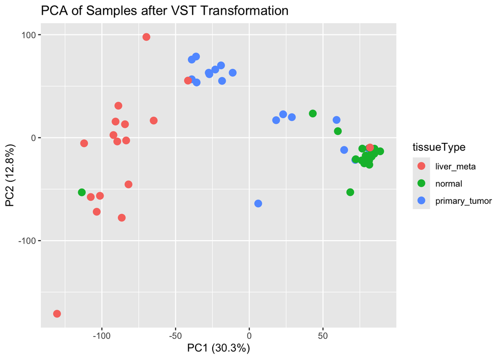

```r
# إنشاء رسم PCA بسيط لتوضيح توزيع العينات بعد التحويل (VST)
ggplot(pca_df, aes(PC1, PC2, color = tissueType)) +
  geom_point(size = 3) +  # رسم النقاط التي تمثل العينات
  labs(
    title = "PCA of Samples after VST Transformation",  # عنوان الرسم
    x = paste0("PC1 (", percentVar[1], "%)"),           # تسمية المحور السيني
    y = paste0("PC2 (", percentVar[2], "%)")            # تسمية المحور الصادي
  )
```

## 7.2 قراءة النتائج من تحليل PCA

- كل نقطة تمثل **عينة واحدة**.
- قرب العينات من بعضها يعني **تشابه أنماط التعبير الجيني** بينها.
- التجمّع الواضح لكل حالة يدل على **اختلاف بيولوجي حقيقي** بين المجموعات.
- أي نقطة بعيدة جدًا (خارج التجمع) قد تشير إلى **عينة شاذة (Outlier)**.

### خلف الكواليس

يقوم تحليل **PCA** بتحويل آلاف الأبعاد (عدد الجينات) إلى عدد قليل من **المكونات الرئيسية (Principal Components)**  
التي تُلخص أكبر قدر من التباين في البيانات:

- **PC1** يمثل أكبر مصدر للتباين في البيانات.
- **PC2** يمثل ثاني أكبر مصدر للتباين.

> عادةً في بيانات **RNA-seq**، هذه المكونات تعكس إما **الاختلاف البيولوجي الحقيقي** بين الحالات  
> أو **عوامل تقنية** مثل عمق القراءة (Library Size).

# 8. رسم Volcano Plot

### 💡 الهدف من هذه الخطوة

يُستخدم **مخطط Volcano plot** لعرض نتائج التحليل التفاضلي بطريقة تجمع بين:

- **حجم التأثير** (log2FoldChange) على المحور السيني.
- **الأهمية الإحصائية** (-log10(padj)) على المحور الصادي.

> كلما صعدت النقطة للأعلى ⬆️ → زادت أهميتها الإحصائية.  
> كلما ابتعدت يمينًا أو يسارًا ⬅️➡️ → كان الفرق في التعبير أكبر.

## 8.1 تجهيز البيانات

```r
res_df <- as.data.frame(res) %>%
  rownames_to_column("gene_id") %>%                  # نقل أسماء الجينات إلى عمود جديد
  mutate(
    padj = if_else(is.na(padj), 1.0, padj),          # تعويض القيم المفقودة في padj
    neg_log10_padj = -log10(padj),                   # حساب -log10(padj) للرسم
    significance = case_when(                        # تحديد حالة كل جين
      padj < 0.05 & log2FoldChange > 1  ~ "Upregulated",
      padj < 0.05 & log2FoldChange < -1 ~ "Downregulated",
      TRUE                              ~ "Not significant"
    )
  )

head(res_df)
```

|  | gene_id | baseMean | log2FoldChange | lfcSE | stat | pvalue | padj | neg_log10_padj | significance |
| --- | --- | --- | --- | --- | --- | --- | --- | --- | --- |
| 1 | ENSG00000000003 | 1824.88077 | 0.40716938 | 0.2516777 | 1.6178207 | 1.057012e-01 | 0.2402182392 | 0.61939402 | Not significant |
| 2 | ENSG00000000005 | 10.85195 | -0.07154855 | 0.4245111 | -0.1685434 | 8.661558e-01 | 0.9251784060 | 0.03377451 | Not significant |
| 3 | ENSG00000000419 | 725.17340 | 0.73520284 | 0.1638666 | 4.4865942 | 7.237072e-06 | 0.0002132159 | 3.67118051 | Not significant |
| 4 | ENSG00000000457 | 311.35784 | -0.18752821 | 0.1216849 | -1.5410965 | 1.232933e-01 | 0.2670018074 | 0.57348580 | Not significant |
| 5 | ENSG00000000460 | 126.36193 | 1.00583629 | 0.2287408 | 4.3972763 | 1.096178e-05 | 0.0002882290 | 3.54026234 | Upregulated |
| 6 | ENSG00000000938 | 163.15327 | 0.54744854 | 0.2607114 | 2.0998260 | 3.574415e-02 | 0.1109377459 | 0.95492066 | Not significant |

## 8.2 رسم مخطط Volcano Plot

بعد تجهيز إطار البيانات (**res_df**)  
سنرسم الآن **مخطط البركان (Volcano Plot)** الذي يُظهر الجينات المتغيرة في التعبير بين المجموعتين.

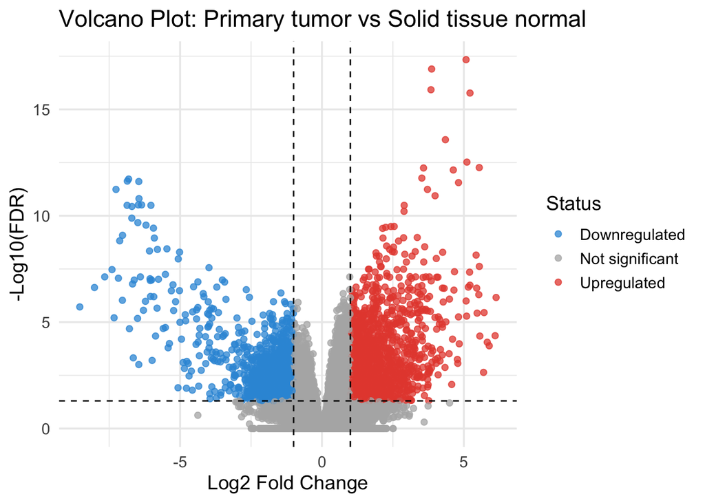

```r
# إنشاء Volcano Plot لعرض الجينات حسب حجم التأثير والدلالة الإحصائية
ggplot(res_df, aes(x = log2FoldChange, y = neg_log10_padj, color = significance)) +
  geom_point(alpha = 0.75, size = 1.8) +  # رسم النقاط (كل نقطة = جين)
  scale_color_manual(values = c(           # تحديد ألوان المجموعات
    "Upregulated" = "#E74C3C",             # أحمر = معبَّر أكثر في الورم
    "Downregulated" = "#3498DB",           # أزرق = منخفض في الورم
    "Not significant" = "grey70"           # رمادي = غير معنوي
  )) +
  geom_vline(xintercept = c(-1, 1), linetype = "dashed", color = "black") +   # خطوط تحدد ±1 في log2FC
  geom_hline(yintercept = -log10(0.05), linetype = "dashed", color = "black") + # خط للدلالة الإحصائية
  labs(
    title = "Volcano Plot: Primary tumor vs Solid tissue normal",  # عنوان الرسم
    x = "Log2 Fold Change",                                        # تسمية المحور السيني
    y = "-Log10(FDR)",                                             # تسمية المحور الصادي
    color = "Status"
  ) +
  theme_minimal(base_size = 14)
```

# 9. عرض الجينات الأكثر تفاضلاً (Boxplot & Violin)

### 💡 الهدف من هذه الخطوة

بعد تحديد الجينات الأكثر اختلافًا في التعبير،  
سنقوم الآن بعرض **أنماط التعبير** لتلك الجينات عبر المجموعتين (الورم والنسيج الطبيعي).  
سنختار **أعلى 10 جينات تفاضلاً** (أي أقل قيمة padj) لعرضها بصريًا.

```r
top10 <- res_df %>%
  filter(!is.na(padj)) %>%        # إزالة القيم المفقودة من العمود padj
  arrange(padj) %>%               # ترتيب الجينات حسب القيمة الإحصائية
  slice_head(n = 10) %>%          # اختيار أول 10 جينات فقط
  pull(gene_id)                   # استخراج أسماء الجينات

norm_counts <- counts(dds, normalized = TRUE)  # الحصول على العدّات بعد normalization

plot_df <- as.data.frame(norm_counts[top10, , drop = FALSE]) %>%  # تحديد الجينات العشرة الأعلى
  rownames_to_column("gene_id") %>%                               # تحويل أسماء الجينات إلى عمود
  pivot_longer(-gene_id, names_to = "sample", values_to = "count") %>%  # تحويل الجدول إلى  (long format)
  left_join(                                                      # ربط البيانات الوصفية الخاصة بالعينات
    as.data.frame(colData(dds)) %>%
      rownames_to_column("sample") %>%
      select(sample, tissueType),
    by = "sample"
  )
plot_df$gene_name <- gene_names[match(plot_df$gene_id, gene_ids)]   # إضافة عمود بأسماء الجينات المقابلة

head(plot_df)
```

| gene_id | sample | count | tissueType | gene_name |
| --- | --- | --- | --- | --- |
| ENSG00000060718 | SRR975551 | 544.206078 | primary_tumor | COL11A1 |
| ENSG00000060718 | SRR975552 | 886.059695 | primary_tumor | COL11A1 |
| ENSG00000060718 | SRR975553 | 5.129824 | primary_tumor | COL11A1 |
| ENSG00000060718 | SRR975554 | 348.217114 | primary_tumor | COL11A1 |
| ENSG00000060718 | SRR975555 | 120.541999 | primary_tumor | COL11A1 |
| ENSG00000060718 | SRR975556 | 8.143811 | primary_tumor | COL11A1 |

## 9.1 Boxplot للجينات العشرة الأعلى تفاضلًا

الآن سنعرض توزيع قيم التعبير الجيني للجينات العشرة الأعلى تفاضلًا  
باستخدام **Boxplot** الذي يُظهر القيم المتوسطة والانحرافات داخل كل مجموعة.

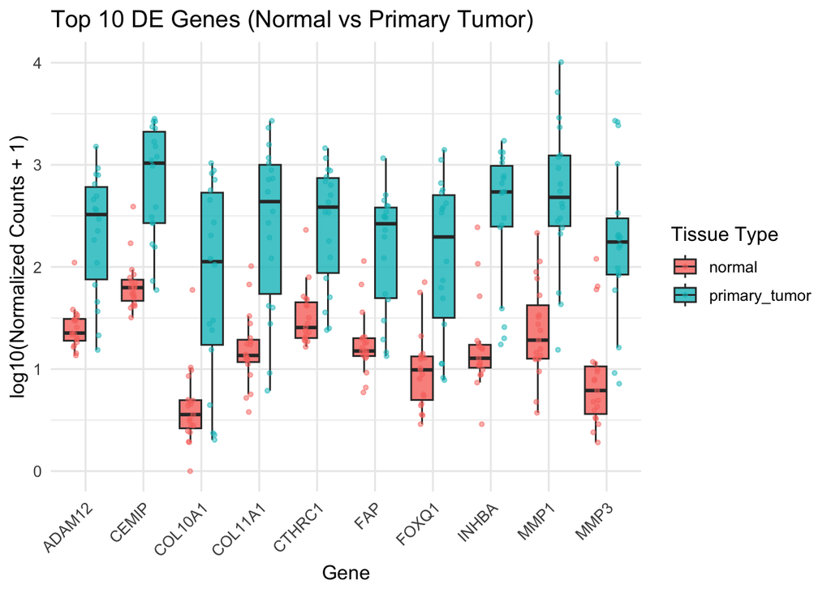

```r
# تصفية المجموعتين المطلوبتين فقط + عمل تحويل لوغاريتمي مسبقًا
plot_df2 <- plot_df %>%
  dplyr::filter(tissueType %in% c("normal", "primary_tumor")) %>%         # إبقاء normal و primary_tumor فقط
  dplyr::mutate(
    tissueType = factor(tissueType, levels = c("normal", "primary_tumor")),# ترتيب ثابت للمجموعتين
    log_count = log10(count + 1)                                           # تحويل لوغاريتمي
  )

# رسم Boxplot
ggplot(plot_df2, aes(x = gene_name, y = log_count, fill = tissueType)) +
  geom_boxplot(outlier.shape = NA, alpha = 0.8,
               position = position_dodge(width = 0.75)) +                 # فصل المجموعتين لكل جين
  geom_jitter(aes(color = tissueType),
              position = position_jitterdodge(jitter.width = 0.2,
                                              dodge.width  = 0.75),
              size = 1, alpha = 0.5) +
  labs(
    title = "Top 10 DE Genes (Normal vs Primary Tumor)",                  # عنوان الرسم
    x = "Gene",                                                           # المحور السيني (أسماء الجينات)
    y = "log10(Normalized Counts + 1)",                                   # المحور الصادي (بعد التحويل)
    fill  = "Tissue Type",
    color = "Tissue Type"
  ) +
  theme_minimal(base_size = 12) +
  theme(axis.text.x = element_text(angle = 45, hjust = 1))                # تدوير أسماء الجينات لسهولة القراءة
```

## 9.2 قراءة نتائج Boxplot

- كل **صندوق (Box)** في الرسم يمثل **توزيع قيم التعبير الجيني** لعينة معينة ضمن مجموعة محددة (مثل *Normal* أو *Primary Tumor*).
- الخط الأوسط داخل الصندوق هو **الوسيط (Median)**، بينما حواف الصندوق تمثل **الربع الأول والثالث (Q1 و Q3)**.
- إذا كان الصندوق الخاص بمجموعة **Primary Tumor** أعلى بوضوح من مجموعة **Normal**، فهذا يشير إلى أن الجين **مرتفع التعبير في العينات الورمية**.
- النقاط الفردية تمثل **قيم العينات المنفردة**، وتساعد على رؤية التوزيع الكامل للقيم.
- استخدام **المقياس اللوغاريتمي** (log10) في المحور الصادي يجعل الفروق الصغيرة أكثر وضوحًا ويقلل من تأثير القيم الكبيرة جدًا.

## 9.3 Violin Plot للجينات نفسها

يوضح **Violin Plot** توزيع قيم التعبير الجيني بشكل أكثر تفصيلًا،  
حيث يجمع بين شكل الكثافة (Distribution) وصندوق القيم (Boxplot)،  
مما يسمح بمقارنة شكل توزيع القيم داخل كل مجموعة (ورم أولي مقابل نسيج طبيعي).

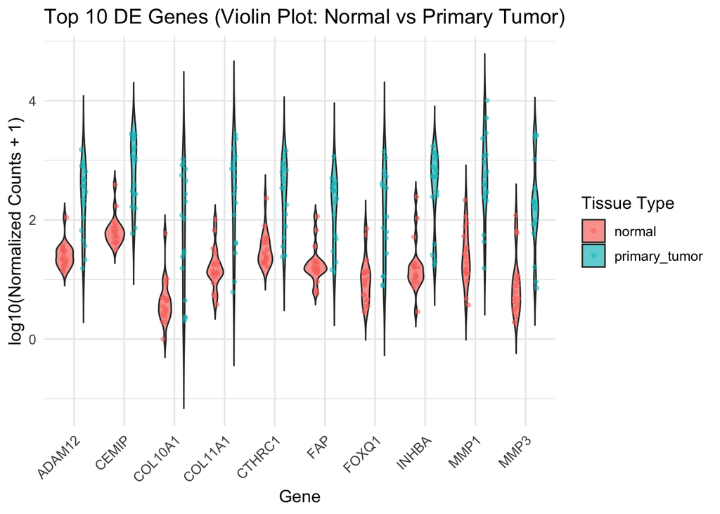

```r
# رسم Violin
ggplot(plot_df2, aes(x = gene_name, y = log_count, fill = tissueType)) +
  geom_violin(trim = FALSE, alpha = 0.7, position = position_dodge(width = 0.75)) + # شكل الكثافة لكل مجموعة
  geom_jitter(aes(color = tissueType),                                              # نقاط العينات فوق المنحنى
              position = position_jitterdodge(jitter.width = 0.2, dodge.width = 0.75),
              size = 1, alpha = 0.5) +
  labs(
    title = "Top 10 DE Genes (Violin Plot: Normal vs Primary Tumor)",      # عنوان الرسم
    x = "Gene",                                                            # المحور السيني (أسماء الجينات)
    y = "log10(Normalized Counts + 1)",                                    # المحور الصادي بعد التحويل
    fill  = "Tissue Type",
    color = "Tissue Type") +
  theme_minimal(base_size = 12) +
  theme(axis.text.x = element_text(angle = 45, hjust = 1))                 # تدوير أسماء الجينات لسهولة القراءة
```

## 9.4 قراءة النتائج

- كل **صندوق أو شكل كمان (Violin)** يمثل توزيع قيم التعبير لجين معيّن داخل كل مجموعة من العينات.
- إذا كانت مجموعة **Primary tumor** تمتلك قيمًا أعلى بوضوح، فهذا يعني أن هذا الجين **مرتفع التعبير في الورم**.
- استخدام **المقياس اللوغاريتمي** يجعل الفروق الصغيرة بين القيم أكثر وضوحًا بصريًا.

## 📘 ملخص هذه المرحلة

✨ في هذه المرحلة قمنا بـ:

1. **تحويل البيانات** لتصحيح التباين (VST).
2. **تحليل العلاقات** بين العينات عبر PCA.
3. **عرض الجينات التفاضلية** عبر Volcano plot.
4. **دراسة الجينات المهمة** عبر Boxplot وViolin plot.

> ✅ النتيجة: أصبح لدينا **فهم بصري شامل للفروق** بين العينات والجينات.  
> سننتقل الآن إلى المرحلة التالية: **تحليل Functional Enrichment Analysis (GO - Reactome)** لفهم الوظائف والمسارات المتأثرة بهذه الجينات

# 10. Functional Enrichment Analysis

بعد أن تعرفنا على الجينات المتغايرة في التعبير، ننتقل الآن للسؤال الأهم:  
*ما هي الوظائف الحيوية والمسارات التي تتأثر بهذه الجينات؟*

## 10.1 مقدمة عن Functional Enrichment Analysis

بعد أن نحصل على قائمة الجينات التي أظهرت فروقًا معنوية في التعبير،  
نحتاج أن نفهم **المغزى البيولوجي** وراء هذه الجينات.  
هل ترتبط بوظائف معينة؟ هل تشارك في مسارات أيضية محددة؟

تحليل (**Functional Enrichment Analysis**) هو ما يجيب عن هذا السؤال.

## 10.2 💡 كيف نقرأ نتائج GO وKEGG وReactome وما الفرق بينهما؟

| القاعدة | المعنى | الغرض |
| --- | --- | --- |
| **Gene Ontology (GO)** | تصنيف شامل للوظائف الجينية. ينقسم إلى ثلاث فئات: 1. Biological Process (BP) — العمليات الحيوية، 2. Molecular Function (MF) — الوظائف الجزيئية، 3. Cellular Component (CC) — المواقع الخلوية. | يصف “ما الذي يفعله الجين وأين ولماذا”. |
| **KEGG Pathways** | قاعدة بيانات للمسارات الأيضية المعروفة. كل مسار يضم مجموعة من الجينات المتفاعلة. | يوضح “كيف تعمل الجينات معًا ضمن شبكة واحدة”. |
| **Reactome** | قاعدة بيانات منظمة للمسارات الحيوية المعتمدة على الأدلة من الأبحاث والتجارب المعملية، تركز على التفاعلات الجزيئية الدقيقة والعمليات الخلوية المفصلة. | تساعد على فهم “التسلسل الدقيق للأحداث البيولوجية داخل الخلية” وتُعد أكثر تفصيلاً من KEGG. |

> ✨ الفرق الأساسي:  
> **GO** تصف *الوظائف الفردية للجينات*.  
> **KEGG** تصف *العلاقات والمسارات المشتركة بين الجينات*.  
> **Reactome** تشرح *الخطوات التفصيلية للتفاعلات داخل المسارات الخلوية*، وغالبًا تكون أكثر دقة وتفصيلاً من KEGG.

## 10.3 الخطوة الأولى: اختيار الجينات المهمة

```r
sig_genes <- res_df %>%
  filter(padj < 0.05, abs(log2FoldChange) > 1) %>%        # اختيار الجينات ذات دلالة إحصائية وفروق واضحة
  mutate(gene_id = str_replace(gene_id, "\\.\\d+$", "")) %>%  # إزالة الرموز  من معرفات Ensembl
  pull(gene_id)                                            # استخراج أسماء الجينات فقط

length(sig_genes)                                          # عرض عدد الجينات المهمة
```

```
## [1] 2909
```

💡 في هذه الخطوة نختار الجينات التي تمتلك **دلالة إحصائية قوية**  
(`padj < 0.05`) وفروقًا واضحة في مستوى التعبير (`|log2FC| > 1`).

## 10.4 تحويل معرفات الجينات إلى ENTREZ

التحليل باستخدام مكتبة **clusterProfiler** يعتمد على معرفات  
**Entrez Gene IDs** وليس **Ensembl IDs**،  
لذلك يجب تحويل المعرفات أولًا باستخدام قاعدة البيانات **org.Hs.eg.db** الخاصة بالإنسان.

```r
entrez_ids <- AnnotationDbi::mapIds(
  org.Hs.eg.db,               # قاعدة بيانات الجينات البشرية
  keys = sig_genes,            # قائمة الجينات المختارة من نتائج DESeq2
  column = "ENTREZID",         # نوع المعرف المطلوب الحصول عليه
  keytype = "ENSEMBL",         # نوع المعرف الحالي المستخدم في القائمة
  multiVals = "first"          # إذا وُجد أكثر من Entrez ID للجين، نأخذ الأول فقط
)
entrez_ids <- na.omit(entrez_ids)  # إزالة أي قيم مفقودة (جينات بدون معرف Entrez)
length(entrez_ids)                 # عرض عدد الجينات التي تم تحويلها بنجاح
```

```
## [1] 2416
```

## 10.5 تنفيذ تحليل GO (Biological Process)

الآن بعد أن أصبح لدينا معرفات الجينات بصيغة **ENTREZ IDs**،  
سنقوم بتنفيذ **(GO Enrichment Analysis)**  
باستخدام مكتبة **clusterProfiler** لتحديد العمليات الحيوية (Biological Processes)  
التي تحتوي على عدد كبير من الجينات المتغيرة في التعبير.

```r
ego <- enrichGO(
  gene = entrez_ids,           # قائمة الجينات المهمة بصيغة Entrez IDs
  OrgDb = org.Hs.eg.db,        # قاعدة بيانات الجينات الخاصة بالإنسان
  keyType = "ENTREZID",        # نوع المعرّف المستخدم
  ont = "BP",                  # نوع تصنيف GO: Biological Process
  pvalueCutoff = 0.05,         # الحد الأقصى للقيمة الاحتمالية قبل اعتبار النتيجة مهمة
  pAdjustMethod = "BH",        # طريقة تصحيح القيم الاحتمالية (Benjamini-Hochberg)
  readable = TRUE              # تحويل المعرفات إلى أسماء جينات مفهومة للقراءة
)

go_df <- as.data.frame(ego)    # تحويل نتائج GO إلى إطار بيانات لسهولة المعالجة
head(go_df)                    # عرض أول 6 صفوف من النتائج
```

|  | ID | Description | GeneRatio | BgRatio | pvalue | p.adjust | qvalue | geneID | Count |
| --- | --- | --- | --- | --- | --- | --- | --- | --- | --- |
| GO:0030198 | GO:0030198 | extracellular matrix organization | 85/1904 | 307/18800 | 2.058337e-18 | 7.355447e-15 | 5.822136e-15 | IBSP/ADAMTS6/COL11A1/FSCN1/ITGA8/FAP/COL5A3/COL19A1/ADAMTS2/…… | 85 |
| GO:0043062 | GO:0043062 | extracellular structure organization | 85/1904 | 308/18800 | 2.567794e-18 | 7.355447e-15 | 5.822136e-15 | IBSP/ADAMTS6/COL11A1/FSCN1/ITGA8/FAP/COL5A3/COL19A1/ADAMTS2/…… | 85 |
| GO:0045229 | GO:0045229 | external encapsulating structure organization | 85/1904 | 310/18800 | 3.981459e-18 | 7.603259e-15 | 6.018290e-15 | IBSP/ADAMTS6/COL11A1/FSCN1/ITGA8/FAP/COL5A3/COL19A1/ADAMTS2/…… | 85 |
| GO:0006959 | GO:0006959 | humoral immune response | 85/1904 | 317/18800 | 1.779476e-17 | 2.548655e-14 | 2.017364e-14 | MASP2/SLC11A1/C6/CD5L/CXCL2/FCER2/C5/HPX/POU2AF1/IL17A/C9/RE…… | 85 |
| GO:0002526 | GO:0002526 | acute inflammatory response | 44/1904 | 113/18800 | 4.807122e-16 | 5.508001e-13 | 4.359807e-13 | ITIH4/CREB3L3/PTGS2/OSM/PIK3CG/TFR2/IL1A/FN1/PLA2G2D/TNFSF4/…… | 44 |
| GO:0072503 | GO:0072503 | cellular divalent inorganic cation homeostasis | 104/1904 | 494/18800 | 2.492047e-13 | 2.379490e-10 | 1.883463e-10 | SLC11A1/P2RY10/SCGN/JPH4/SLC8A3/NTSR1/CEMIP/CALB1/JPH1/GRIN2…… | 104 |

## 10.6 رسم نتائج GO – Barplot

الآن سنقوم برسم **أهم العمليات الحيوية (GO terms)**  
التي أظهرت تغيير معنوي في مجموعة الجينات المتغايرة في التعبير.  
يمثل هذا الرسم عدد الجينات المشاركة في كل عملية حيوية (Count)،  
ويُلوَّن حسب درجة الأهمية الإحصائية (**p.adjust**).

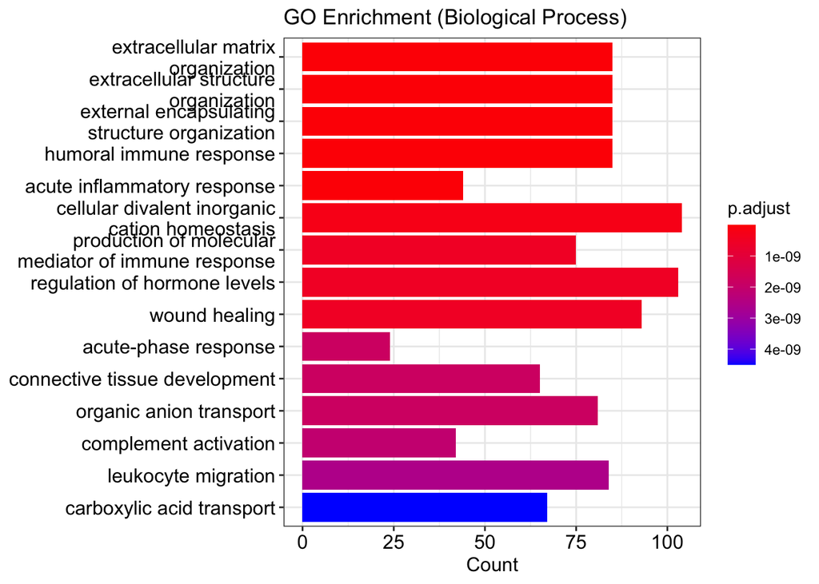

```r
# رسم أهم العمليات الحيوية (GO terms) الغنية بالجينات المتغايرة
barplot(
  ego,                          #  ناتج من enrichGO()
  showCategory = 15,            # عرض أعلى 15 عملية حيوية فقط
  title = "GO Enrichment (Biological Process)",  # عنوان الشكل
  font.size = 12,               # حجم الخطوط داخل الرسم
  xlab = "Number of Genes",     # تسمية المحور السيني
  color = "p.adjust"            # تلوين الأعمدة حسب قيمة  p.adjust
)
```

## 10.7 رسم نتائج GO – Dotplot

يوضّح **Dotplot** نتائج تحليل GO بطريقة تجمع بين  
عدد الجينات المشاركة (**Count**) ونسبة الجينات ضمن كل عملية (**GeneRatio**)  
مع تلوين النقاط بحسب مستوى (**p.adjust**).  
كل نقطة تمثل عملية حيوية (Biological Process).

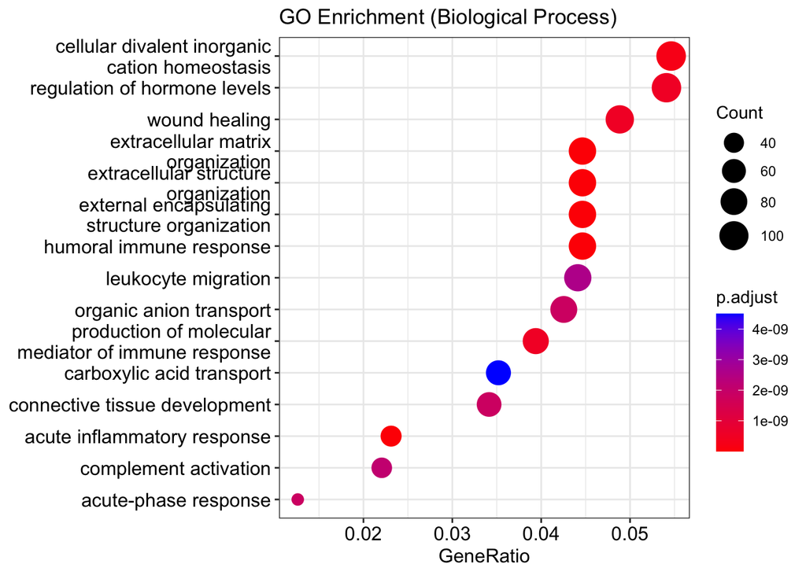

```r
# رسم Dotplot لأهم العمليات الحيوية (GO terms)
dotplot(
  ego,                           #  الناتج من enrichGO()
  showCategory = 15,             # عرض أعلى 15 عملية حيوية
  title = "GO Enrichment (Biological Process)",  # عنوان الرسم
  font.size = 12
)
```

## 10.8 قراءة النتائج

- كل صف في الجدول يمثل **عملية حيوية (Biological Process)** تحتوي على عدد كبير من الجينات المتغيرة في التعبير.
- كلما **زاد عدد الجينات (Count)** و**انخفضت قيمة p.adjust**، زادت أهمية هذه العملية الحيوية.
- النقاط الكبيرة في الرسم (Dotplot) تمثل عمليات تشمل عددًا أكبر من الجينات المتأثرة.

## 10.9 تنفيذ تحليل Reactome

الآن سننفّذ تحليل **ReactomePA**  
لتحديد **المسارات الحيوية (biological pathways)** التي تتأثر بالجينات المتغيرة في التعبير.  
يركّز هذا التحليل على **التفاعلات الجزيئية الدقيقة** والعمليات الخلوية ضمن شبكة تفاعلات شاملة مبنية على قاعدة بيانات **Reactome**،  
مما يساعد على فهم **كيف تساهم الجينات معًا في تنفيذ العمليات الحيوية داخل الخلية**.

```r
ereact <- enrichPathway(
  gene = entrez_ids,
  organism = "human",
  pvalueCutoff = 0.05,
  readable = TRUE
)

ereact_df <- as.data.frame(ereact) # تحويل النتائج إلى إطار بيانات
head(ereact_df)                   # عرض أول 6 صفوف
```

|  | ID | Description | GeneRatio | BgRatio | pvalue | p.adjust | qvalue | geneID | Count |
| --- | --- | --- | --- | --- | --- | --- | --- | --- | --- |
| R-HSA-1474244 | R-HSA-1474244 | Extracellular matrix organization | 96/1208 | 300/10891 | 3.790735e-23 | 4.874885e-20 | 4.576813e-20 | ITGAL/CD44/IBSP/MUSK/VCAN/LAMC3/COL11A1/ACTN1/ITGA8/CEACAM1/…… | 96 |
| R-HSA-1442490 | R-HSA-1442490 | Collagen degradation | 34/1208 | 64/10891 | 1.296351e-16 | 8.335537e-14 | 7.825867e-14 | COL11A1/COL5A3/COL19A1/MMP2/COL9A3/MMP11/MMP9/COL1A1/COL12A1…… | 34 |
| R-HSA-1474228 | R-HSA-1474228 | Degradation of the extracellular matrix | 49/1208 | 140/10891 | 4.532967e-14 | 1.943132e-11 | 1.824321e-11 | CD44/COL11A1/COL5A3/COL19A1/MMP2/COL9A3/MMP11/MMP9/TIMP1/COL…… | 49 |
| R-HSA-216083 | R-HSA-216083 | Integrin cell surface interactions | 36/1208 | 85/10891 | 1.412544e-13 | 4.541329e-11 | 4.263652e-11 | ITGAL/CD44/IBSP/ITGA8/COL5A3/COL9A3/ICAM5/COMP/ITGB8/COL1A1/…… | 36 |
| R-HSA-2022090 | R-HSA-2022090 | Assembly of collagen fibrils and other multimeric structures | 29/1208 | 61/10891 | 9.411572e-13 | 2.420656e-10 | 2.272647e-10 | COL11A1/COL5A3/COL9A3/MMP9/COL1A1/COL12A1/COL9A1/LOX/COL7A1/COL10A1/PXDN/COL5A1/LOXL2/COL4A2/CTSV/MMP7/MMP20/MMP13/COL8A1/MMP3/COL6A3/COL1A2/COL3A1/COL4A3/COL18A1/COL4A1/COL27A1/COL5A2/COL15A1 | 29 |
| R-HSA-1474290 | R-HSA-1474290 | Collagen formation | 35/1208 | 90/10891 | 6.119102e-12 | 1.311528e-09 | 1.231335e-09 | COL11A1/COL5A3/COL19A1/ADAMTS2/COL9A3/MMP9/COL1A1/COL12A1/CO…… | 35 |

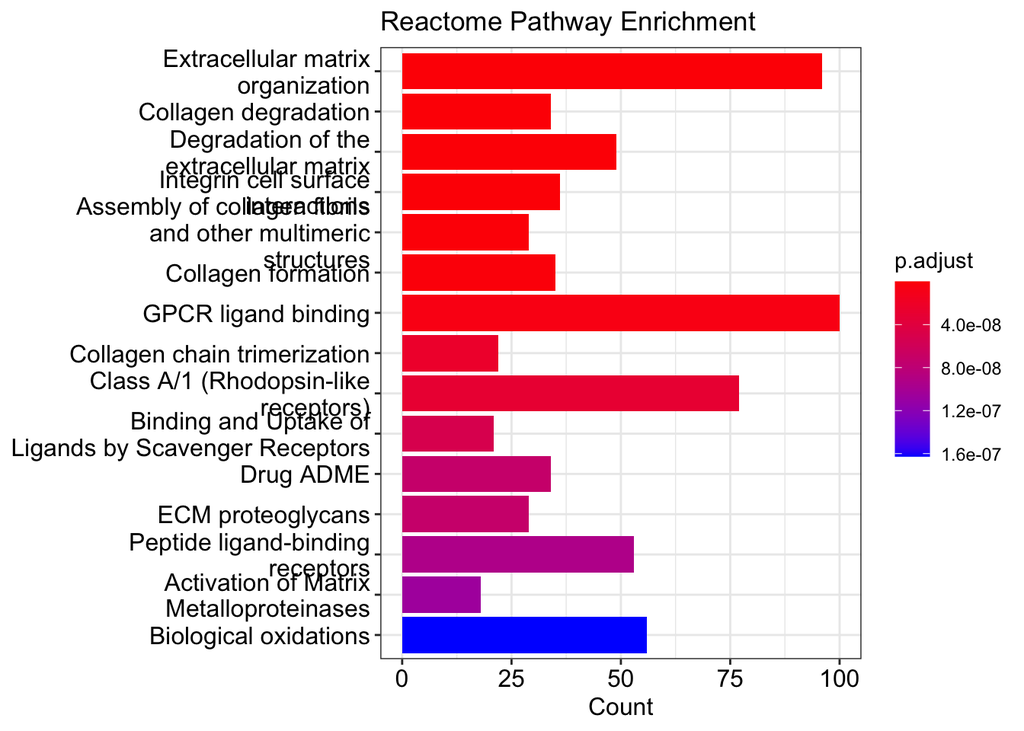

```r
# Barplot: عرض أهم المسارات الأيضية حسب عدد الجينات
barplot(ereact,
        showCategory = 15,                 # عرض أعلى 15 مسارًا فقط
        title = "Reactome Pathway Enrichment", # عنوان الرسم
        font.size = 12)                    # حجم النصوص
```

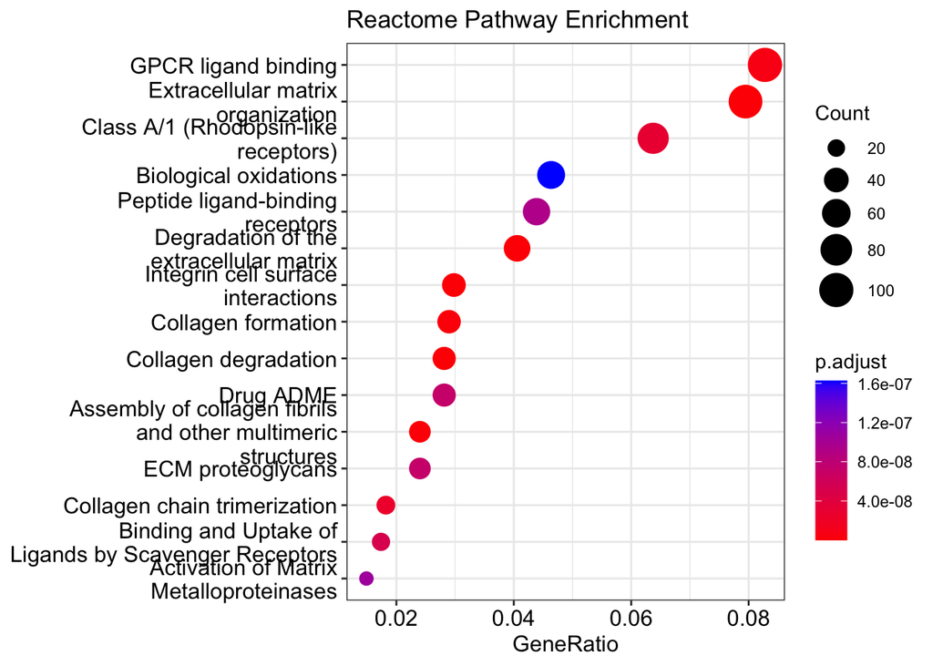

```r
# Dotplot: عرض المسارات مع توضيح نسبة الجينات والدلالة الإحصائية
dotplot(ereact,
        showCategory = 15,                 # عرض أعلى 15 مسارًا
        title = "Reactome Pathway Enrichment",
        font.size = 12)
```

## 10.11 قراءة النتائج

- يمثل كل صف في جدول **Reactome** مسارًا أيضيًا يحتوي على عدد من الجينات المتغايرة في التعبير.
- انخفاض قيمة **p.adjust** يشير إلى أن هذا المسار أكثر احتمالًا أن يكون مرتبطًا بالمرض أو الظاهرة قيد الدراسة.
- أمثلة شائعة قد تظهر في مثل هذه التحليلات:  
  *Cell cycle*, *p53 signaling*, *Metabolic pathways*.

## 📘 ملخص هذه المرحلة

✨ في هذا الجزء تعلمنا:

| المرحلة | ما تعلمناه | الأدوات المستخدمة |
| --- | --- | --- |
| **تحويل المعرفات** | كيفية تحويل الجينات المهمة إلى معرفات Entrez صالحة للتحليل | `AnnotationDbi` |
| **تحليل الإثراء** | تنفيذ تحليلي **GO** و **Reactome** لفهم المعاني البيولوجية للجينات المتغايرة | `clusterProfiler` |
| **التصور البياني** | عرض النتائج بطريقة تفاعلية وواضحة باستخدام **ggplot2** | `ggplot2` |

# 📘 خاتمة الورشة

## 💡 ملخص ما تعلمناه خلال اليوم

| المرحلة | ما تعلمناه | الأدوات المستخدمة |
| --- | --- | --- |
| **قراءة البيانات** | فهم ملفات (**counts**) وملف (**metadata**) وربطهما معًا | tidyverse |
| **تصفية الجينات** | إزالة الجينات منخفضة التعبير لتقليل الضجيج وتحسين دقة التحليل | base R |
| **التحليل التفاضلي** | مقارنة المجموعات باستخدام نموذج **DESeq2** | DESeq2 |
| **التصور البياني** | تحليل **PCA** و **Volcano** و **Box/Violin plots** | ggplot2 |
| **Functional Enrichment** | إجراء تحليل **Functional Enrichment (GO and Reactome)** لتفسير العمليات والمسارات الحيوية المتأثرة | clusterProfiler |

# التطبيقات العملية

في نهاية الورشة، نرجو منكم تطبيق ما تعلمتموه عمليًا  
من خلال تنفيذ مقارنة جديدة بين:  
> **Primary tumor vs Metastatic liver tissue**

الهدف من هذه التمارين هو **تعزيز الفهم التطبيقي** لكل خطوة تم تنفيذها في الورشة.  
يمكن لكل مجموعة اختيار **أحد المهام التالية** وإنجازها خلال الجلسة العملية:

### المهام المقترحة

1. **إسقاط العينة الشاذة وإعادة رسم الـ PCA**
- حدد العينة الخارجة عن التجمع العام (Outlier) في مخطط PCA.
- استبعدها وأعد رسم الـ PCA باستخدام البيانات المتبقية.
- ناقش كيف تغيّر توزيع العينات بعد الإزالة.
2. **رسم Volcano Plot للمقارنة الجديدة**
- استخدم نفس خطوات التحليل التفاضلي لكن للمقارنة:  
  `Metastatic liver tissue` مقابل `Primary tumor`.
- ارسم Volcano Plot جديدًا وفسّر الجينات الأكثر تغيّرًا.
3. **رسم Boxplot لأكثر 10 جينات تفاضلًا**
- اختر أعلى 10 جينات ذات أقل قيمة `padj`.
- ارسم Boxplot للتعبير الجيني لتلك الجينات بين المجموعتين.
- استخدم مقياس `log10` للمحور العمودي لتسهيل المقارنة.
4. **تنفيذ تحليل GO (لجينات Upregulated فقط)**
- استخرج الجينات التي **padj < 0.05** و**log2FC > 1**.
- نفّذ تحليل GO عليها فقط باستخدام `enrichGO()`.
- اعرض النتائج في **Barplot** وناقش أهم العمليات الحيوية المتأثرة.
5. **تنفيذ تحليل KEGG ومقارنة أهم 5 مسارات**
- نفّذ تحليل `enrichKEGG()` لنفس الجينات السابقة.
- قارن بين **أهم 5 مسارات** من KEGG ونتائج GO السابقة.

# 📚 مصادر إضافية للقراءة

| المصدر | الوصف |
| --- | --- |
| 📗 [DESeq2 documentation](https://bioconductor.org/packages/devel/bioc/vignettes/DESeq2/inst/doc/DESeq2.html) | دليل استخدام مكتبة DESeq2 الرسمية |
| 📘 [clusterProfiler manual](https://yulab-smu.top/biomedical-knowledge-mining-book/) | شرح مفصل لتحليل GO وKEGG |
| 📙 [RNA-seq analysis guide](https://hbctraining.github.io/Intro-to-bulk-RNAseq/schedule/links-to-lessons.html) | دورة تدريبية مفتوحة في تحليل RNA-seq |
| 📓 [Introduction to ggplot2](https://ggplot2.tidyverse.org/) | مرجع لتخصيص الرسومات باستخدام ggplot2 |

# ✨ ختام الورشة

🎉 **انتهت ورشة اليوم بنجاح!**

في هذه الورشة تعلّمنا كيف ننتقل من **بيانات counts الخام**  
إلى **تفسير بيولوجي متكامل** يوضح معنى التغيّرات في التعبير الجيني.

> 💡 فهمك لكل خطوة من التنظيف إلى التحليل الإحصائي ثم التفسير ،  
> هو ما يجعلك قادرًا على تنفيذ تحليلات RNA-seq بثقة واحترافية.

نتمنى أن تكون هذه التجربة قد أضافت لك معرفة عملية واضحة  
وأن تساعدك على تحليل بياناتك البحثية القادمة بسهولة أكبر.